```r
library(dplyr)
library(purrr)
library(twitteR)
```

1. To find difference between Trump’s own tweets and his twitter handle
2. Difference in Trump’s tweeting when on Android and Iphone
3. Below methods using Text Mining and Sentiment Analysis we examine the difference in Trump’s tweeting from Iphone and Android

```r
library(tidyr)
load(url("http://varianceexplained.org/files/trump_tweets_df.rda"))
tweets<-trump_tweets_df%>%select(id,statusSource,text,created)%>%extract(statusSource,"source","Twitter for (.*?)<")%>%filter(source %in% c("iphone","Android"))
```

1. Using Sentiment analysis, we can find that Tweets from Android phone are by Trump himself while tweets from Iphone are generic announcements with pictures and links Terms : 1)favoriteCount:The number of Tweets this user has liked in the account’s lifetime. 2)statusSource: Source status of the tweet

```r
df <- trump_tweets_df %>%
  select(favoriteCount, text, statusSource) %>%
  extract(statusSource, "source", "Twitter for (.*?)<") %>%
  filter(source %in% c("iPhone", "Android"))
df
```

```
## # A tibble: 1,390 x 3
##    favoriteCount text                                                     source
##            <dbl> <chr>                                                    <chr>
##  1          9214 "My economic policy speech will be carried live at 12:1~ Andro~
##  2          6981 "Join me in Fayetteville, North Carolina tomorrow eveni~ iPhone
##  3         15724 "#ICYMI: \"Will Media Apologize to Trump?\" https://t.c~ iPhone
##  4         19837 "Michael Morell, the lightweight former Acting Director~ Andro~
##  5         34051 "The media is going crazy. They totally distort so many~ Andro~
##  6         29831 "I see where Mayor Stephanie Rawlings-Blake of Baltimor~ Andro~
##  7         19223 "Thank you Windham, New Hampshire! #TrumpPence16 #MAGA ~ iPhone
##  8         19543 ".@Larry_Kudlow - 'Donald Trump Is the middle-class gro~ iPhone
##  9         75488 "I am not just running against Crooked Hillary Clinton,~ Andro~
## 10         23661 "#CrookedHillary is not fit to be our next president! #~ iPhone
## # ... with 1,380 more rows
```

The above dataset contains tweets from twitter page of trump 628 tweets from iPhone and 762 tweets from Android.

```r
library(purrr)
library(dplyr)
library(tidyr)
library(tibble)
```

```r
load(url("http://varianceexplained.org/files/trump_tweets_df.rda"))
```

Terms: created: When the messages was created text: Text of the Direct Message

```r
df <- trump_tweets_df %>%
  select(created, id, text, statusSource) %>%
  extract(statusSource, "source", "Twitter for (.*?)<") %>%
  filter(source %in% c("iPhone", "Android"))
glimpse(df)
```

```
## Rows: 1,390
## Columns: 4
## $ created <dttm> 2016-08-08 15:20:44, 2016-08-08 13:28:20, 2016-08-08 00:05:54~
## $ id      <chr> "762669882571980801", "762641595439190016", "76243965891133849~
## $ text    <chr> "My economic policy speech will be carried live at 12:15 P.M. ~
## $ source  <chr> "Android", "iPhone", "iPhone", "Android", "Android", "Android"~
```

```r
library(ggplot2)
library(lubridate)
library(scales)
library(stringr)
```

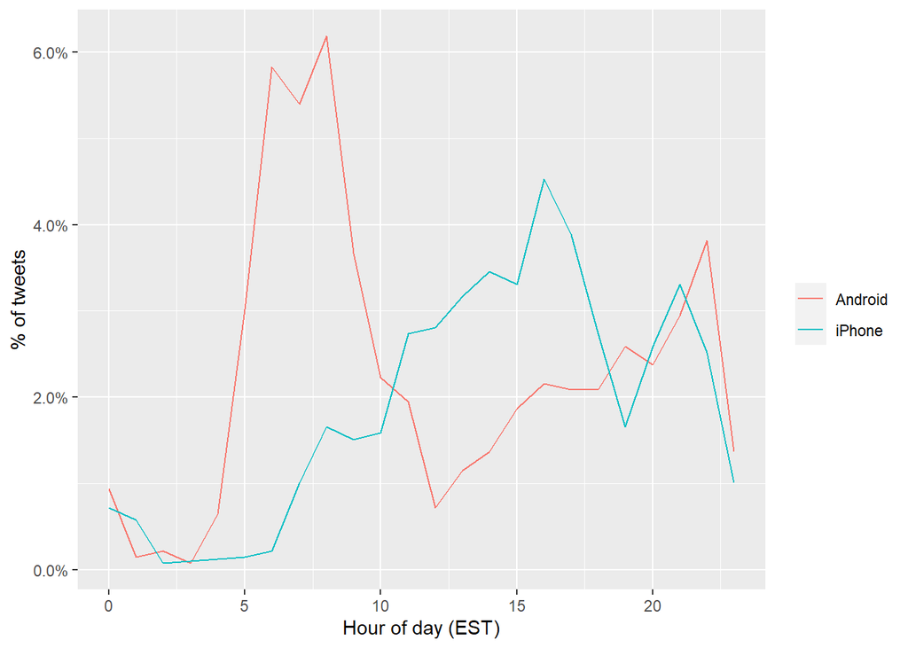

```r
df %>%
  count(source, hour = hour(with_tz(created, "EST"))) %>%
  mutate(percent = n / sum(n)) %>%
  ggplot(aes(hour, percent, color = source)) +
  geom_line() +
  scale_y_continuous(labels = percent_format()) +
  labs(x = "Hour of day (EST)",
       y = "% of tweets",
       color = "")
```

From the above graph , we can infer Trump does a lot of his personal tweeting in morning hours of the day on his Android While more public tweeting happens from Iphone during evening hours of the day.

```r
library(ggplot2)
library(lubridate)
library(scales)
library(stringr)
tweet_picture_counts<-df%>%
  filter(!str_detect(text,'^"'))%>%
  count(source,picture=ifelse(str_detect(text,"t.co"),
                              "Picture/link","NoPicture/link"))
tweet_picture_counts
```

```
## # A tibble: 4 x 3
##   source  picture            n
##   <chr>   <chr>          <int>
## 1 Android NoPicture/link   543
## 2 Android Picture/link      10
## 3 iPhone  NoPicture/link   199
## 4 iPhone  Picture/link     423
```

Terms:str_detect: Detect the presence or absence of a pattern in a string. The Above dataframe shows the number of tweets from Trump’s Android phone which further provides indication of Trump’s sentiments

```r
tweet_picture_counts<-df%>%
  filter(!str_detect(text,'^"'))%>%
  count(source,picture=ifelse(str_detect(text,"t.co"),
                              "Picture/link","NoPicture/link"))
tweet_picture_counts
```

```
## # A tibble: 4 x 3
##   source  picture            n
##   <chr>   <chr>          <int>
## 1 Android NoPicture/link   543
## 2 Android Picture/link      10
## 3 iPhone  NoPicture/link   199
## 4 iPhone  Picture/link     423
```

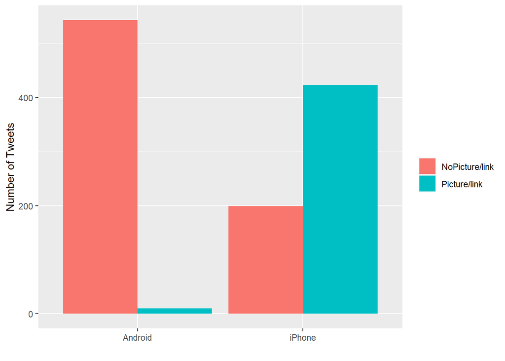

```r
ggplot(tweet_picture_counts,aes(source,n,fill=picture))+
  geom_bar(stat="identity",position="dodge")+
  labs(x="",y="Number of Tweets",fill="")
```

From the above graph , We can infer that almost 50 times more non-Picture/link based tweets are tweeted from Trump’s Android than picture based Also from Trump’s Iphone , more than twice picture based / link tweets have been tweeted than Non-picture based

COMPARISON OF WORDS

```r
library(tidytext)
reg<-"([^A-Za-z\\d#@']|'(?![A-Za-z\\d#@]))"
tweet_words<-df%>%
filter(!str_detect(text,'^"'))%>%
mutate(text=str_replace_all(text,"https://t.co/[A-Za-z\\d]+|&amp;",""))%>%
unnest_tokens(word,text,token="regex",pattern=reg)%>%
filter(!word %in% stop_words$word,
       str_detect(word,"[a-z]"))
tweet_words
```

```
## # A tibble: 8,753 x 4
##    created             id                 source  word
##    <dttm>              <chr>              <chr>   <chr>
##  1 2016-08-08 15:20:44 762669882571980801 Android economic
##  2 2016-08-08 15:20:44 762669882571980801 Android policy
##  3 2016-08-08 15:20:44 762669882571980801 Android speech
##  4 2016-08-08 15:20:44 762669882571980801 Android carried
##  5 2016-08-08 15:20:44 762669882571980801 Android live
##  6 2016-08-08 15:20:44 762669882571980801 Android enjoy
##  7 2016-08-08 13:28:20 762641595439190016 iPhone  join
##  8 2016-08-08 13:28:20 762641595439190016 iPhone  fayetteville
##  9 2016-08-08 13:28:20 762641595439190016 iPhone  north
## 10 2016-08-08 13:28:20 762641595439190016 iPhone  carolina
## # ... with 8,743 more rows
```

The above dataframe is to analyse the difference in sentiment of words from Trump’s Android and Iphone Tweets Based on the dataframe common stopwords are removed

CALCULATION OF LOGODDS RATIO : TO FIND THE MOST USED WORDS FROM ANDROID RELATIVE TO IPHONE log2(# in Android+1/Total Android+1/# in iPhone+1Total iPhone+1)

```r
android_iphone_ratios<-tweet_words%>%
count(word,source)%>%
filter(sum(n)>=5)%>%
spread(source,n,fill=0)%>%
ungroup()%>%
mutate_each(funs((.+1)/sum(.+1)),-word)%>%
mutate(logratio=log2(Android/iPhone))%>%
arrange(desc(logratio))
android_iphone_ratios
```

```
## # A tibble: 2,560 x 4
##    word    Android   iPhone logratio
##    <chr>     <dbl>    <dbl>    <dbl>
##  1 badly   0.00188 0.000156     3.59
##  2 crazy   0.00174 0.000156     3.48
##  3 weak    0.00161 0.000156     3.37
##  4 spent   0.00134 0.000156     3.10
##  5 joke    0.00121 0.000156     2.95
##  6 mails   0.00121 0.000156     2.95
##  7 strong  0.00121 0.000156     2.95
##  8 talking 0.00121 0.000156     2.95
##  9 ago     0.00107 0.000156     2.78
## 10 brexit  0.00107 0.000156     2.78
## # ... with 2,550 more rows
```

Here the odds are in favour of Trump’s Tweets from Android than Iphone since logodds are greater than 1 .

SENTIMENT ANALYSIS The NRC Emotion Lexicon is a list of English words and their associations with eight basic emotions (anger, fear, anticipation, trust, surprise, sadness, joy, and disgust) and two sentiments (negative and positive).

```r
nrc <- get_sentiments("nrc") %>%
     mutate(lexicon = "nrc",
            words_in_lexicon = n_distinct(word))
nrc
```

```
## # A tibble: 13,875 x 4
##    word        sentiment lexicon words_in_lexicon
##    <chr>       <chr>     <chr>              <int>
##  1 abacus      trust     nrc                 6456
##  2 abandon     fear      nrc                 6456
##  3 abandon     negative  nrc                 6456
##  4 abandon     sadness   nrc                 6456
##  5 abandoned   anger     nrc                 6456
##  6 abandoned   fear      nrc                 6456
##  7 abandoned   negative  nrc                 6456
##  8 abandoned   sadness   nrc                 6456
##  9 abandonment anger     nrc                 6456
## 10 abandonment fear      nrc                 6456
## # ... with 13,865 more rows
```

We measure the sentiments expressed from Trump’s Android and Iphone Tweets based on the word count under each of the two categories

```r
sources<-tweet_words%>%
group_by(source)%>%
mutate(total_words=n())%>%
ungroup()%>%
distinct(id,source,total_words)
sources
```

```
## # A tibble: 1,172 x 3
##    id                 source  total_words
##    <chr>              <chr>         <int>
##  1 762669882571980801 Android        4901
##  2 762641595439190016 iPhone         3852
##  3 762439658911338496 iPhone         3852
##  4 762425371874557952 Android        4901
##  5 762400869858115588 Android        4901
##  6 762284533341417472 Android        4901
##  7 762110918721310721 iPhone         3852
##  8 762106904436961280 iPhone         3852
##  9 762104411707568128 Android        4901
## 10 762016426102296576 iPhone         3852
## # ... with 1,162 more rows
```

`inner_join()`: includes all rows in `x` and `y`. complete: Complete a data frame with missing combinations of data

```r
by_source_sentiment<-tweet_words%>%
  inner_join(nrc,by="word")%>%
  count(sentiment,id)%>%
  ungroup()%>%
  complete(sentiment,id,fill=list(n=0))%>%
  inner_join(sources)%>%
  group_by(source,sentiment,total_words)%>%
  summarize(words=sum(n))%>%
  ungroup()
head(by_source_sentiment)
```

```
## # A tibble: 6 x 4
##   source  sentiment    total_words words
##   <chr>   <chr>              <int> <dbl>
## 1 Android anger               4901   321
## 2 Android anticipation        4901   256
## 3 Android disgust             4901   207
## 4 Android fear                4901   268
## 5 Android joy                 4901   199
## 6 Android negative            4901   560
```

In order to measure how likely Andorid Account is emotionally charged relative to Iphone Poisson Test: Performs an exact test of a simple null hypothesis about the rate parameter in Poisson distribution, or for the ratio between two rate parameters.

```r
library(broom)
sentiment_differences<-by_source_sentiment%>%
  group_by(sentiment)%>%
  do(tidy(poisson.test(.$words,.$total_words)))
sentiment_differences
```

```
## # A tibble: 10 x 9
## # Groups:   sentiment [10]
##    sentiment  estimate statistic  p.value parameter conf.low conf.high method
##    <chr>         <dbl>     <dbl>    <dbl>     <dbl>    <dbl>     <dbl> <chr>
##  1 anger          1.49       321 2.19e- 5      274.    1.24       1.81 Comparis~
##  2 anticipat~     1.18       256 1.08e- 1      239.    0.966      1.44 Comparis~
##  3 disgust        1.71       207 9.59e- 6      169.    1.34       2.21 Comparis~
##  4 fear           1.56       268 1.89e- 5      226.    1.26       1.93 Comparis~
##  5 joy            1.01       199 9.57e- 1      198.    0.814      1.25 Comparis~
##  6 negative       1.71       560 3.91e-13      458.    1.47       1.98 Comparis~
##  7 positive       1.06       555 3.64e- 1      541.    0.933      1.21 Comparis~
##  8 sadness        1.62       303 1.15e- 6      252.    1.33       1.99 Comparis~
##  9 surprise       1.17       159 2.17e- 1      149.    0.908      1.51 Comparis~
## 10 trust          1.13       369 1.26e- 1      350.    0.963      1.33 Comparis~
## # ... with 1 more variable: alternative <chr>
```

Trump’s negative sentiments are statistically significant as compared to Positive sentiments.